# Week 02: Decision Trees

## 2D Interaction PDP

PDPs can also show the **joint effect** of two features simultaneously — useful for detecting interaction effects:

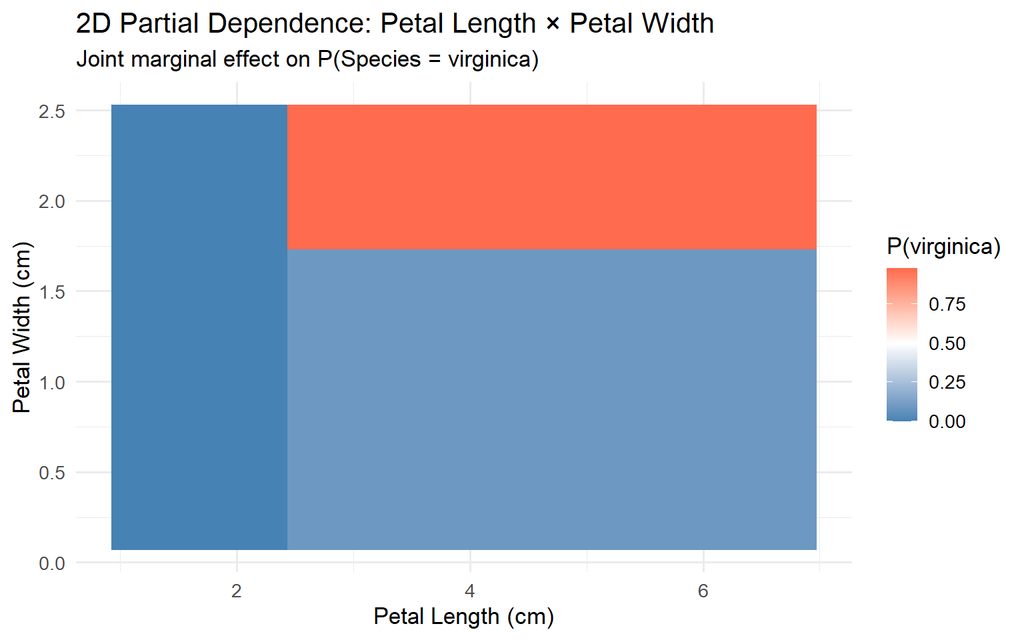

```r
# Manual 2D PDP: grid over both features, average P(virginica) across all obs
pl_grid <- seq(min(iris$Petal.Length), max(iris$Petal.Length), length.out = 40)
pw_grid <- seq(min(iris$Petal.Width),  max(iris$Petal.Width),  length.out = 40)
grid_2d <- expand.grid(Petal.Length = pl_grid, Petal.Width = pw_grid)

grid_2d$yhat <- apply(grid_2d, 1, function(row) {
  d_temp <- iris
  d_temp$Petal.Length <- row["Petal.Length"]
  d_temp$Petal.Width  <- row["Petal.Width"]
  mean(predict(iris_full_tree, d_temp, type = "prob")[, "virginica"])
})

ggplot(grid_2d, aes(x = Petal.Length, y = Petal.Width, fill = yhat)) +
  geom_tile() +
  scale_fill_gradient2(low = "steelblue", mid = "white", high = "tomato",
                       midpoint = 0.5, name = "P(virginica)") +
  labs(title    = "2D Partial Dependence: Petal Length × Petal Width",
       subtitle  = "Joint marginal effect on P(Species = virginica)",
       x = "Petal Length (cm)", y = "Petal Width (cm)") +
  theme_minimal(base_size = 13)
```

**Key limitation highlighted by Boehmke & Greenwell [2]:** Decision trees produce **rigid, non-smooth prediction surfaces** — the step-function nature is clearly visible in the 2D PDP as hard rectangular boundaries. MARS and neural networks produce smoother surfaces. This is a fundamental characteristic of tree-based models.

## Feature Importance vs. Partial Dependence — Summary

| Tool | Answers | Shows Direction? | Shows Shape? |
| --- | --- | --- | --- |
| **Feature Importance** | *Which features matter?* | No | No |
| **PDP (1D)** | *How does feature X affect predictions?* | Yes | Yes |
| **PDP (2D)** | *How do X and Y interact?* | Yes | Yes |

> Always use both together: importance tells you *which* features to investigate; PDPs tell you *how* they behave. **[2]**

# Knowledge Check

Test your understanding with these questions from the textbook:

**1.** What is the approximate depth of a Decision Tree trained *without restrictions* on a training set with 1 million instances?

> *Hint: Trees are approximately balanced, so depth ≈ log₂(1,000,000) ≈ ?*

**2.** Is a node’s Gini impurity generally **lower** or **greater** than its parent’s Gini impurity? Is it always the case, or just generally?

**3.** Your Decision Tree is overfitting the training set. Should you try **increasing** or **decreasing** `max_depth`?

**4.** Your Decision Tree is underfitting. Would **scaling the input features** help? Why or why not?

**5.** If training takes 1 hour on 1 million instances, roughly how long would it take on 10 million instances?

> *Hint: Training complexity is O(n × m log₂ m). How does this scale?*

```
## Answers (unhide to reveal):
```

```
## 1. ~20 levels (log2(1,000,000) ≈ 20)
```

```
## 2. Generally LOWER — CART minimizes child impurity. Always lower for training data,
```

```
##  but may not improve much if the gain is near zero.
```

```
## 3. DECREASE max_depth — a shallower tree has less flexibility to overfit.
```

```
## 4. NO — Decision Trees do not use distances or gradients, so feature scale is irrelevant.
```

```
## 5. ~11.7 hours — 10x more data → 10 * log2(10M)/log2(1M) ≈ 11.7x longer.
```

**6.** You build a decision tree on a dataset and notice that `Age` is used in 5 different splits while `Income` is used in only 1. Which feature will have higher importance, and why?

**7.** A PDP for a regression tree on feature `x` shows a flat line at ŷ = 42 from x = 10 to x = 50, then a sharp jump to ŷ = 65 at x = 51, then flat again. What does this tell you about the tree’s split structure?

# References

The following references were used in the development of this tutorial. Citations are formatted in **IEEE style**.

**[1]** A. Géron, *Hands-On Machine Learning with Scikit-Learn, Keras, and TensorFlow*, 2nd ed. Sebastopol, CA, USA: O’Reilly Media, 2019.

**[2]** B. C. Boehmke and B. M. Greenwell, *Hands-On Machine Learning with R*. Boca Raton, FL, USA: CRC Press, 2020. [Online]. Available: https://bradleyboehmke.github.io/HOML/DT.html

**[3]** L. Breiman, J. H. Friedman, R. A. Olshen, and C. J. Stone, *Classification and Regression Trees*. Boca Raton, FL, USA: Chapman & Hall/CRC, 1984.

**[4]** T. M. Therneau and E. J. Atkinson, “An Introduction to Recursive Partitioning Using the RPART Routines,” Mayo Foundation, Rochester, MN, USA, Tech. Rep., 1997.

**[5]** B. M. Greenwell, “pdp: An R Package for Constructing Partial Dependence Plots,” *The R Journal*, vol. 9, no. 1, pp. 421–436, 2017. *(Partial dependence methodology implemented manually in this tutorial via grid prediction.)*

**[6]** B. M. Greenwell and B. C. Boehmke, “Variable Importance Plots — An Introduction to the vip Package,” *The R Journal*, vol. 12, no. 1, pp. 343–366, 2020. *(Feature importance extracted directly from `rpart`’s `$variable.importance` field.)*

**[7]** R. A. Fisher, “The Use of Multiple Measurements in Taxonomic Problems,” *Annals of Eugenics*, vol. 7, no. 2, pp. 179–188, 1936.